# Posterior Predictive Checking for Partially Observed Stochastic Epidemic Models

This repository contains `R` code for implementing the methods presented in

> Aristotelous G., Kypraios, T. and O’Neil, P.D. (2022) Posterior Predictive Checking for Partially Observed Stochastic Epidemic Models, *Bayesian Analysis*; to appear.

which addresses the problem of assessing the fit of stochastic epidemic models to data.

Two novel model assessment methods are developed and presented in the manuscript above, based on disease progression curves, namely the *distance method* and the *position-time method*. Both methods provide visual and quantitative outputs with meaningful interpretations.

We illustrate both methods by applying them to data from an outbreak which occurred in a boarding school in England and led to 102 cases among 1307 students [Smith *et al.*, 2009](https://www.eurosurveillance.org/content/10.2807/ese.14.27.19263-en).

We first source the necessary `R` functions which implement the proposed methods.

```r
source("functions.R")
```

The observed data are provided in the form of new daily cases (see Figure 1 in [Smith *et al.*, 2009](https://www.eurosurveillance.org/content/10.2807/ese.14.27.19263-en).) which we transform to individual removal times, under our assumption that case-detections correspond to recoveries.

A homogeneously mixing SIR model with an Exponential infectious period distribution was fitted within a Bayesian framework. We then produced 500 replicated removal data sets from their respective posterior predictive distributions, conditioning on the final size being the same as for the observed data.

We load both the real data (`R.obs`) as well as the 500 samples from the posterior predictive distribution of the removal times (`R.STAR`):

```r
load("example_Smith2009.RData")
R.obs
```

```
##   [1]  0  1  1  7  8 10 12 12 13 13 14 14 14 15 16 16 16 16 17 17 17 18 18 19 19
##  [26] 20 20 20 21 21 21 21 21 21 21 22 22 22 22 22 22 22 22 23 23 23 23 23 23 23
##  [51] 23 24 24 24 24 24 24 24 24 24 24 25 25 25 25 25 26 26 26 26 26 26 26 26 26
##  [76] 26 27 27 27 27 27 27 28 28 28 28 28 28 28 28 28 28 29 29 29 29 30 30 30 30
## [101] 31 32
```

# Distance Method

We implement the *distance method* by calling the function `distance.method` which takes as argument (i) a vector with the observed removal times (`R.obs`) and (ii) a matrix containing the replicated removal curves (`R.STAR`). There are also some optional arguments in the function `distance.method` which are concerned with various plotting settings.

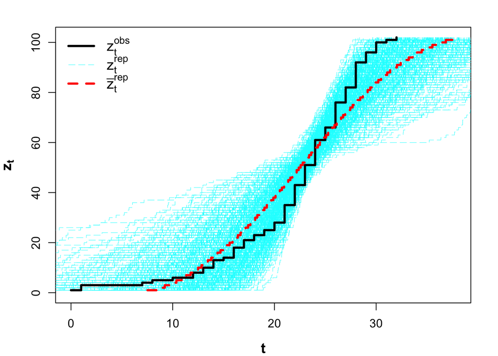

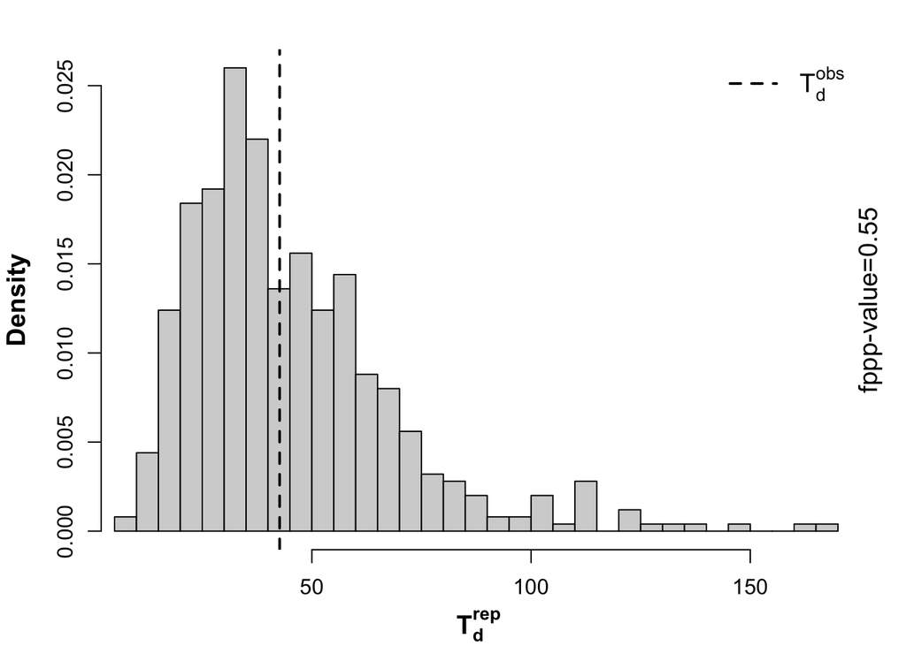

```
## [1] "fppp-value=0.55"
```

```r
distance.method(R.obs = R.obs, R.STAR = R.STAR)
```

The `distance.method` functions produces first a plot of the observed removal curve (as provided in `R.obs`) and the (shifted) removal curves from the posterior predictive distribution (as provided in `R.STAR`) with the mean removal curve, $\bar{z}_{t}^{rep}$ (red, dashed line), and the observed removal curve, $z_t^{obs}$ (black, solid line), imposed. Furthermore, it produces a histogram of the 500 replications from the posterior predictive distribution of the distance, $T_d^{rep}$, with the observed distance, $T_d^{obs}$ (black, dashed line), overlaid and the corresponding folded ppp-value stated.

# Position-time method:

We implement the *position-time* method using the function `position.time.method` which similarly to the `distance.method` function, requires the same two arguments; a vector with the observed removal times (`R.obs`) and a matrix with replicated removal curves (`R.STAR`):

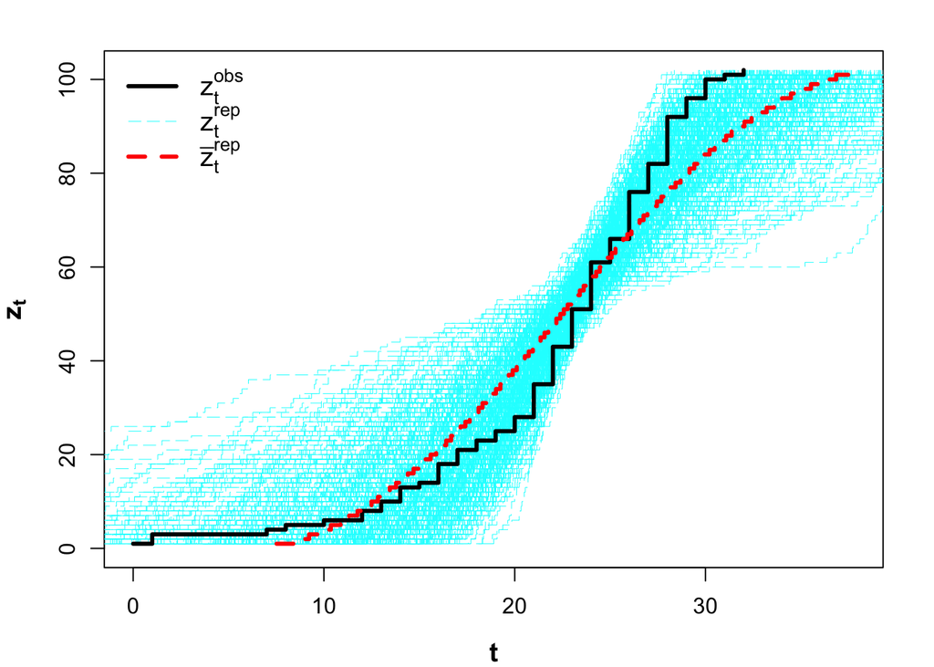

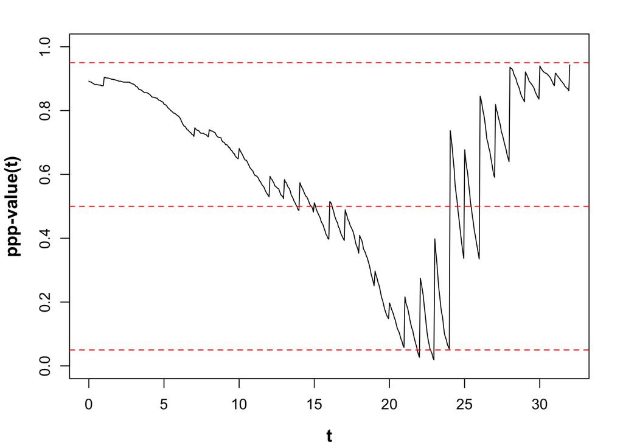

```
##   [0,0.1] (0.1,0.2] (0.2,0.3] (0.3,0.4] (0.4,0.5] (0.5,0.6] (0.6,0.7] (0.7,0.8]
##     0.050     0.066     0.042     0.060     0.098     0.138     0.100     0.140
## (0.8,0.9]   (0.9,1]
##     0.238     0.068
## [1] "sqrtmse=0.28"
```

```r
position.time.method(R.obs = R.obs, R.STAR = R.STAR)
```

The output of the `position.time.function` also provides first a plot of the observed removal curve (as provided in `R.obs`) and the (shifted) removal curves from the posterior predictive distribution (as provided in `R.STAR`) with the mean removal curve, $\bar{z}_{t}^{rep}$ (red, dashed line), and the observed removal curve, $z_t^{obs}$ (black, solid line), imposed.

It then produces a history plot of the ppp-value$(t)$ with the 0.05, 0.5 and 0.95 inverse quantiles (red, dashed lines) imposed. The function also returns a table with the proportion of time that $z_t^{obs}$ spends in the inverse quantile intervals of $z_t^{rep}$ from the position-time method.

For more details about each of the two methods we refer the reader to the manuscript.